# Introduction to point pattern analysis for ecologists

Lionel Hertzog

July 24, 2017

# Introduction to point pattern analysis

Point pattern analysis is a set of techniques to analyze spatial point data. In ecology this type of analysis may arise in several context but make specific assumptions regarding the ways the data were generated, so let’s first see what type of ecological data may or may not be relevant for point pattern analysis.

## What data for point pattern analysis?

The most important assumptions of point pattern analysis is that both the number and the location of the points need to be *random*. In addition, we need to know the area that was sampled (so-called *window*). Examples where point pattern analysis is relevant:

- Tree position in a forest plot
- Ant nests in a grassland patch

Examples not suited for point pattern analysis:

- Community composition at *a priori* defined subplots forming a regular grid within a larger plot
- The position of fixed number of bird’s nests is recorded within a given area

Examples that may or may not be suited to point pattern analysis:

- Radiotracking data of animal movements (see the numerous techniques available for this specific type of data)
- Tree position in a forest plot is mapped every year forming a replicated point pattern (see specific chapter in the Bradley book)

## Point pattern in R

The *spatstat* package provide a large number of functions and classes to work with point pattern data. I will use an example dataset throughout to show some of the (numerous) capacities of this package. This dataset consist of the location of plant and ant nests within a coastal dune system in western europe, you can download the data from this link.

### Creating a point pattern from existing data

```r
#load the dataset
dat <- read.table("data/Dataset mieren af.csv",sep=";",head=TRUE)
#put the coords in meters
dat$X <- dat$X/100
dat$Y <- dat$Y/100

#creating the point pattern
(all_pp <- ppp(dat[,"X"],dat[,"Y"],owin(c(0,15),c(0,10))))
```

```
## Planar point pattern: 2320 points
## window: rectangle = [0, 15] x [0, 10] units
```

```r
class(all_pp)
```

```
## [1] "ppp"
```

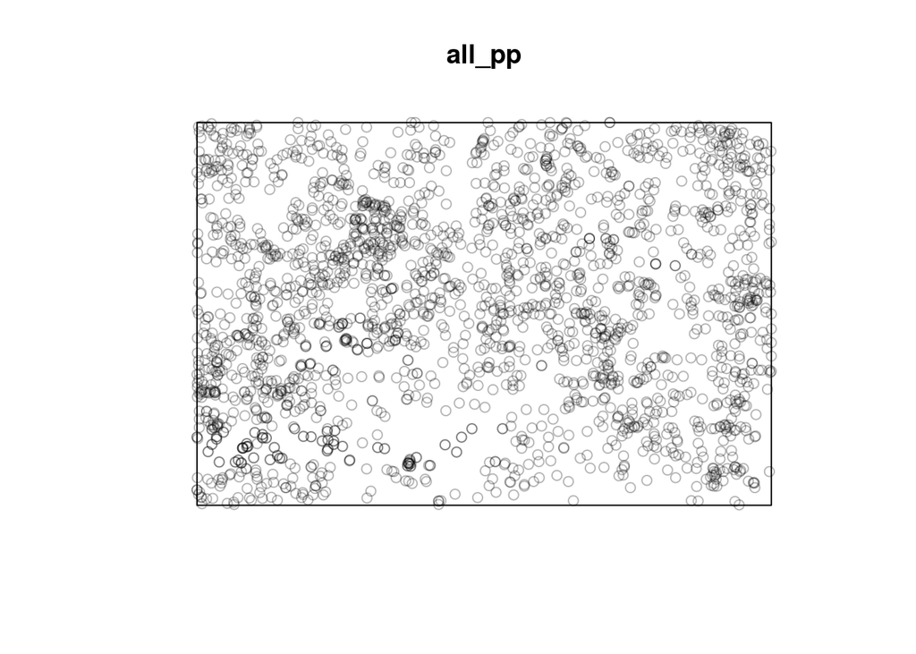

```r
plot(all_pp)
```

The *spatstat* package use a special class (the “ppp” class) to deal with point pattern. To create ppp objects we need to use the *ppp* function, it requires at least three arguments: (i) the x coordinates, (ii) the y coordinates and (iii) the window or the area over which we have recorded the point pattern. For this last argument we can use the *owin* function to create a window object that will be used by the *ppp* function. The *owin* function requires two arguments: (i) the range of x coordinates and (ii) the range of y coordinates.

### Data manipulation of point pattern objects

```r
#a first manipulation would be to add information to each points
#the so-called marks, in this example we could add the species names
marks(all_pp) <- dat$Soort

#a second manipulation could be to remove any duplicated points
#to do this we can use simple row indexing
all_pp <- unique(all_pp)
#add the unit
unitname(all_pp) <- c("meter","meter")

summary(all_pp)
```

```
## Marked planar point pattern:  2263 points
## Average intensity 15.08667 points per square meter
##
## Coordinates are given to 2 decimal places
## i.e. rounded to the nearest multiple of 0.01 meter
##
## Multitype:
##                        frequency   proportion   intensity
## Arenaria_serpyllifolia         1 0.0004418913 0.006666667
## Asparagus_officinalis          3 0.0013256740 0.020000000
## Crepis_sp.                   311 0.1374282000 2.073333000
## Erodium_sp.                  138 0.0609810000 0.920000000
## Hieracium_umbellatum          10 0.0044189130 0.066666670
## Hypochaeris_radicata         433 0.1913389000 2.886667000
## Jasione_montana              137 0.0605391100 0.913333300
## Leontodon_saxatilis          416 0.1838268000 2.773333000
## Myrmica_sabuleti               3 0.0013256740 0.020000000
## Oenothera_sp.                188 0.0830755600 1.253333000
## Oenothera_sp._dood            29 0.0128148500 0.193333300
## Sedum_acre                     4 0.0017675650 0.026666670
## Senecio_inaequidens          300 0.1325674000 2.000000000
## Senecio_jacobaea              19 0.0083959350 0.126666700
## Tetramorium_caespitum        105 0.0463985900 0.700000000
## Viola_curtisii               166 0.0733539500 1.106667000
##
## Window: rectangle = [0, 15] x [0, 10] meter
## Window area = 150 square meter
## Unit of length: 1 meter
```

```r
#we could subset the point pattern using the marks
ant_pp <- subset(all_pp,marks=="Tetramorium_caespitum")
#in that case we do not need the marks any more
ant_pp <- unmark(ant_pp)
```

The concept of marks is a pretty important one so I’ll spend some extra words on it. Marks can be numeric or factor vector of the same length as the point pattern, these are extra informations that were collected for each points. In this example this is the species names of plants and ants recorded, but this could also be the height of the trees or the number of eggs in bird nests. The marks will automatically be used when plotting the point pattern, try “plot(all_pp)” for instance. Note that you can also pass data frame as marks to have multivariate marks.

A second cool set of manipulation is based on the window, basically one can subset a point pattern to specific windows:

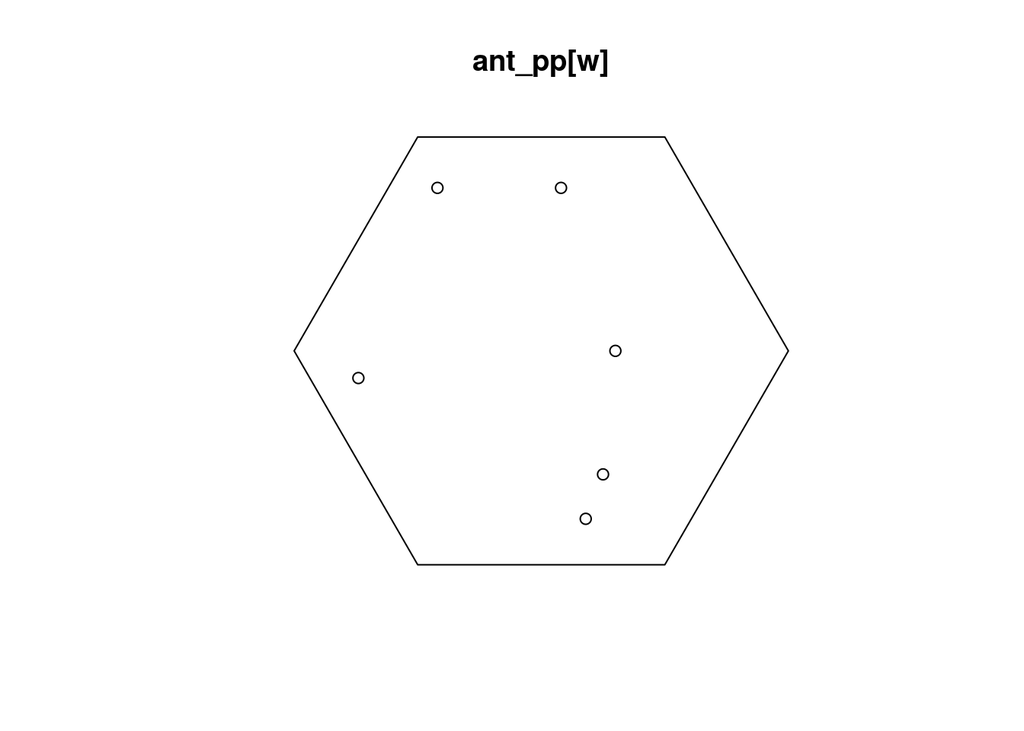

```r
w <- hexagon(centre=c(5,5))
plot(ant_pp[w])
```

See ?owin for the many ways available to create windows.

A final manipulation that I’d like to mention now is the *split.ppp* function, can you guess what it is doing?

```r
#split based on the species names
split_pp <- split(all_pp)
class(split_pp)
```

```
## [1] "splitppp" "ppplist"  "solist"   "list"
```

```r
as.matrix(lapply(split_pp,npoints),ncol=1)
```

```
##                        [,1]
## Arenaria_serpyllifolia 1
## Asparagus_officinalis  3
## Crepis_sp.             311
## Erodium_sp.            138
## Hieracium_umbellatum   10
## Hypochaeris_radicata   433
## Jasione_montana        137
## Leontodon_saxatilis    416
## Myrmica_sabuleti       3
## Oenothera_sp.          188
## Oenothera_sp._dood     29
## Sedum_acre             4
## Senecio_inaequidens    300
## Senecio_jacobaea       19
## Tetramorium_caespitum  105
## Viola_curtisii         166
```

```r
#one could also use: by(all_pp,marks(all_pp),npoints)

#split based on a window
split_ant_pp <- split(ant_pp,f=w)
summary(split_ant_pp)
```

[output not shown]

I just scratched here the many functionalities that are implemented in the *spatstat* packages to manipulate point pattern, have a look at the help pages, vignettes and online forum to help you out in this critical step.

### Exploratory analysis of point patterns

The first important thing is to find out if the point pattern was generated by one intensity function, in that case th epoint pattern is homogenous, or if the point pattern was generated by several instensity functions, in that case the point pattern is inhomogenous. This is an important first step in any analysis of point pattern as most functions and models assume homogeneity by default. I will show here two ways to infer the homogeneity of a point pattern: (i) simulation and (ii) quadrat count

The first approach consist in simulating completely spatially random point patterns based on the average intensity in the observed point pattern. If the density estimates of the observed and simulated point patterns are similar then we have evidence that the point pattern is homogenous.

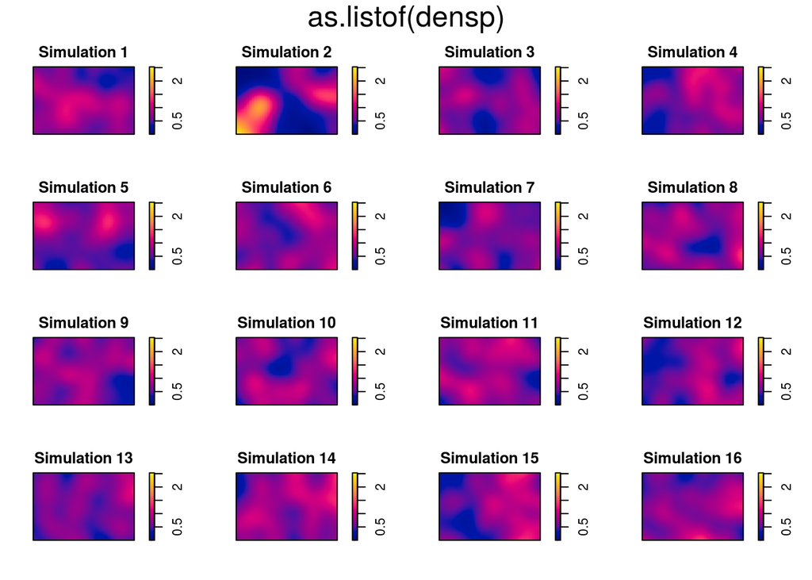

```r
#compare the observed density to randomly simulated ones based on the intensity

#select a random position for the observed data in the figure
pos <- sample(1:16,1)
#simulate 15 CSR point pattern
simp <- rpoispp(lambda = intensity(ant_pp),win = Window(ant_pp),nsim=15)
#replace the simulated set at the pos'th position by the observed dataset
tmp <- simp[[pos]]
simp[[pos]] <- ant_pp
simp[[16]] <- tmp
names(simp)[16] <- "Simulation 16"
#compute density estimates
densp <- density(simp)
#plot, can you detect which one was the observed dataset?
par(mfrow=c(4,4),mar=c(0,0,4,4))
plot(as.listof(densp),zlim=range(unlist(lapply(densp,range))))
```

If you can find the real dataset within the simulated ones then there is evidence that an inhomogenous process generated the data. You have to use special functions in that case.

The second approach consist in dividing the window in quadrats and to count the number of points per quadrat. Using a chi-square test one can infer if the point pattern was homogenous (p > 0.05) or inhomogenous (p < 0.05):

```r
quadrat.test(ant_pp)
```

```
##
##  Chi-squared test of CSR using quadrat counts
##  Pearson X2 statistic
##
## data:  ant_pp
## X2 = 92.857, df = 24, p-value = 9.655e-10
## alternative hypothesis: two.sided
##
## Quadrats: 5 by 5 grid of tiles
```

The output tell us that the null hypothesis of the point pattern being generated by complete spatial random process is rejected, we have some evidence that the point pattern is inhomogenous. There is one issue with this approach: one need to define the size of the quadrats, the default value is to create 25 quadrats, but I find it hard to come up with reasonable explanation for using that or other values.